# Lab 7: Ordered Outcome Models

Mateo Villamizar Chaparro

October 2, 2020

## **Important Information**:

1. **Office hours**: Tuesdays from 4:00-5:00 pm (https://duke.zoom.us/j/94327288065)
2. **Labs**: Fridays from 10:15-11:30 (https://duke.zoom.us/j/93156474311)

## **Today’s dataset**

For todays class we are going to use the “lab7.csv” file in sakai. The file contains information for an online omnibus survey launched in April 2019. The survey had information about US citizen’s perceptions on a hypothetical program that would help migrants relocate and work in the respondent’s county after a natural disaster. The survey also camptured other individual characteristics and political attitutudes of the respondents. The list of variables is as follows:

```r
final <- read.csv("lab7.csv")
# summary(final)
```

```r
stargazer::stargazer(final, header = F,  type = 'html')
```

| Statistic | N | Mean | St. Dev. | Min | Pctl(25) | Pctl(75) | Max |
| --- | --- | --- | --- | --- | --- | --- | --- |
| mig_exp_revcod | 663 | 4.947 | 1.709 | 1 | 4 | 6 | 7 |
| emp | 663 | 0.406 | 0.491 | 0 | 0 | 1 | 1 |
| mig_visas | 663 | 3.006 | 1.298 | 1 | 2 | 4 | 5 |
| democrat | 663 | 0.373 | 0.484 | 0 | 0 | 1 | 1 |
| republican | 663 | 0.296 | 0.457 | 0 | 0 | 1 | 1 |
| white | 663 | 0.751 | 0.433 | 0 | 1 | 1 | 1 |
| black | 663 | 0.104 | 0.306 | 0 | 0 | 0 | 1 |
| hispanic | 663 | 0.033 | 0.179 | 0 | 0 | 0 | 1 |
| unemp_cpm | 663 | 0.033 | 0.179 | 0 | 0 | 0 | 1 |
| edu | 663 | 3.633 | 1.411 | 1 | 2 | 5 | 6 |
| female | 663 | 0.698 | 0.459 | 0 | 0 | 1 | 1 |
| inc | 663 | 5.656 | 3.534 | 1 | 3 | 8 | 13 |
| age | 663 | 47.094 | 16.475 | 17 | 33 | 61 | 88 |

## **Ordered Outcome Models**

### *What are ordinal variables?*

- Variables that define categories
- Variable that are ordered along one category
- The exact difference betwen categories is unknown (How much is the difference between slightly agree and agree?)
- The best example for ordinal variables are always likert or support scales like the one in today’s dataset.

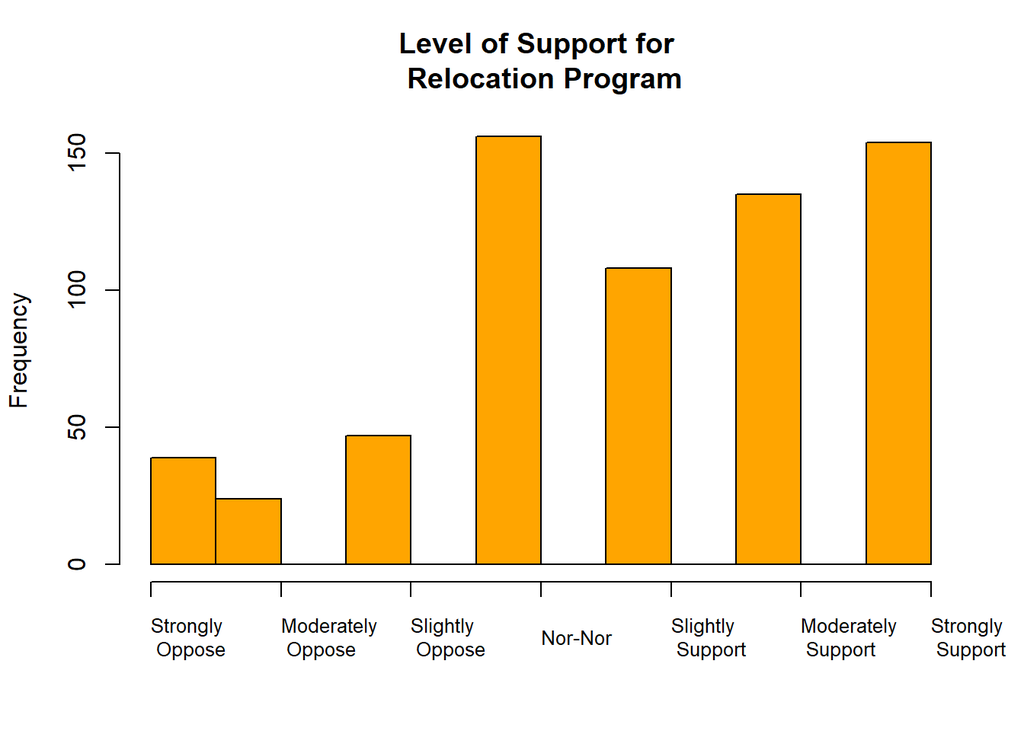

```r
# Using basic R
hist(final$mig_exp_revcod,
     main = "Level of Support for \n Relocation Program",
     xlab = "",
     xaxt = 'n', col = "orange")
labels <- c("Strongly \n Oppose", "Moderately \n Oppose", "Slightly \n Oppose",
                              "Nor-Nor", "Slightly \n Support", "Moderately \n Support", "Strongly \n Support")
axis(side = 1, labels = FALSE)
text(x = 1:7,                      # Number of labels
     y = par("usr")[3] - 20,       # move labels to the bottom of the plot see ?par
     labels = labels,              # names for the labels
     xpd = NA,                     # Change the regioin where the axis is going to show see ?xpd
     srt = 0,                      # Degrees of rotation
     adj = 0,                      # How below to start, it is a position argument
     cex = 0.8)                    # Font size
```

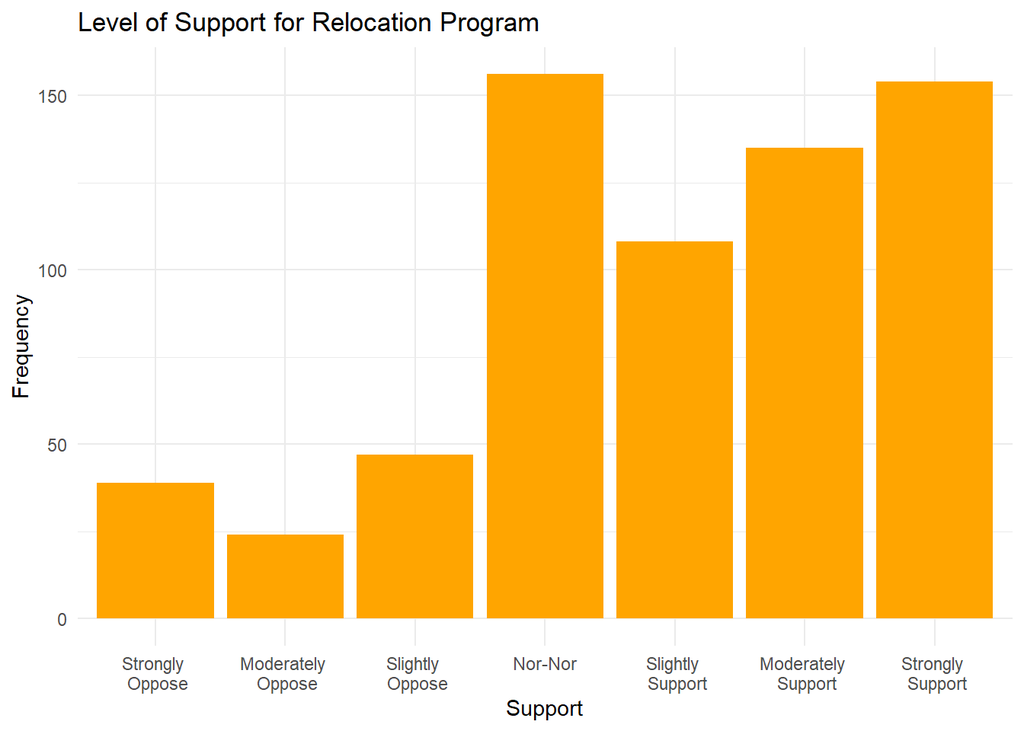

```r
# Using ggplot
labels <- c("Strongly \n Oppose", "Moderately \n Oppose", "Slightly \n Oppose", "Nor-Nor", "Slightly \n Support", "Moderately \n Support", "Strongly \n Support")
ggplot(final, aes(x = mig_exp_revcod)) + geom_bar(fill = "orange") +
  scale_x_discrete(limits = c("1", "2", "3", "4", "5", "6", "7"),
                   labels = labels) +
  labs(title = "Level of Support for Relocation Program",
       x = "Support",
       y = "Frequency") +
  theme_minimal()
```

These types of variables can also be treated by:

- **Dichotomozing the variable of interest:** easier to estimate and interpret; estimates are more consistent. BUT, we lose efficiency and the selection of attributes is very subjective
- **Estimate the model using OLS:** easier to estimate and interpret. It could be a good approach if your variable is approximately equidistant, has many values and is not skewed. BUT, the model is wrong since we would have predicitons out of bounds and the model is heteroskedastic.

### *How the model is constructed*

The easier way to understand the estimation of ordered models is thinking as if we had a latent variable problem. For this, we need to estimates the cutoffs of the latent varaible as well as the probabilities for each cutoff. This is why when calculating ordered models you would calculate two sets of parameters: the coefficients for the model $\beta_i$ and the cut-off points $\tau_i$. The model for the latent can be explained by its stochastic and systematic components as follows:

$$\begin{split}
Y_i^* &\sim P(y_i^*|\mu_i) \\
\mu_i &= X_i\beta
\end{split}$$
However, we observe that:

$$y_{ij} = \left\{
\begin{array}{ll}
1 & \tau_{j-1,i}\leq y_i^*< \tau_{j,i} \\
0 & Otherwise \\
\end{array}
\right.$$

For our relocation program support variable is exactly the same as saying that:
$$\begin{split}
y_i=StronglyOppose &\Leftrightarrow \tau_0 \leq y_i^* < \tau_1 \\
y_i=ModeratelyOppose &\Leftrightarrow \tau_1 \leq y_i^* < \tau_2 \\
y_i=SlighltyOppose &\Leftrightarrow \tau_2 \leq y_i^* < \tau_3 \\
y_i=NorNor &\Leftrightarrow \tau_3 \leq y_i^* < \tau_4 \\
y_i=SlighltySupport &\Leftrightarrow \tau_4 \leq y_i^* < \tau_5 \\
y_i=ModeratelySupport &\Leftrightarrow \tau_5 \leq y_i^* < \tau_6 \\
y_i=StronglySupport &\Leftrightarrow \tau_6 \leq y_i^* < \tau_7 \\
\end{split}$$

$$\begin{split}
Pr(Y_i=j) = Pr(Y_{ij}=1)&=Pr(\tau_{j-1,i} \leq y_i^* < \tau_{j,i}) \\
&=Pr(\tau_{j-1,i} \leq X_i\beta + \epsilon < \tau_{j,i}) \\
&=Pr(\tau_{j-1,i}- X_i\beta \leq \epsilon < \tau_{j,i}+X_i\beta) \\
&= \int_{\tau_{j-1,i}- X_i\beta}^{\tau_{j,i}+X_i\beta} \epsilon \quad d\epsilon \\
&= F(\tau_{j,i}-X_i\beta) - F(\tau_{j-1,i}-X_i\beta)
\end{split}$$

Here **F** is a cummulative density distribution (either a logistic or a normal density function). However, this is the probability of only one of our categories, and we have 7 of them. In order to calcualte this, we create a new indicator variable $y_{ij}$ that is equal to 1 when the respondent chose that category and 0 otherwise. Thus, for an indvidual in today’s dataset that strongly opposed the program is:

$$\begin{split}
Pr(y_{StrOP,i} =1) &= Pr(y_{StrOp,i}=1)^1 \times Pr(y_{ModOP,i}=1)^0 \times Pr(y_{SliOpi}=1)^0 \\
& \times Pr(y_{NN,i}=1)^0 \times Pr(y_{SliSup,i}=1)^0 \times Pr(y_{ModSup,i}=1)^0 \\
& \times Pr(y_{StrSup,i}=1)^0 \\
\end{split}$$
More specifically:

$$\begin{split}
Pr(y_{StrOP,i} =1) &= (F(\tau_{StrOp,i}+X_i\beta) - 0)^1 \\
&\times (F(\tau_{ModOp,i}+X_i\beta) - F(\tau_{StrOp,i}-X_i\beta))^0 \\
&\times (F(\tau_{SliOp,i}+X_i\beta) - F(\tau_{ModOp,i}-X_i\beta))^0 \\
&\times (F(\tau_{NorNor,i}+X_i\beta) - F(\tau_{SliOp,i}-X_i\beta))^0 \\
&\times (F(\tau_{SliSup,i}+X_i\beta) - F(\tau_{NorNor,i}-X_i\beta))^0 \\
&\times (F(\tau_{ModSup,i}+X_i\beta) - F(\tau_{SliSup,i}-X_i\beta))^0 \\
& \times (1-F(\tau_{StrSup,i}+X_i\beta))^0 \\
\end{split}$$

Which is equivalent to:
$$Pr(y_{j,i} =1) = \prod_{j=1}^J Pr(y_{ij}=1)^{y_{ji}}$$
But, we have 663 (N) individuals in our data, thus we need to multiply this probability for the number of people in our dataset to get the likelihood function. Hence:
$$L(\beta, \tau |X,Y) = \prod_{i=1}^N\prod_{j=1}^J Pr(y_{ij}=1)^{y_{ji}}$$

Calculating the log-likelihood:

$$ll(\beta, \tau |X,Y) = \sum_{i=1}^N\sum_{j=1}^J y_{ji} \ln (Pr(y_{ij}=1))$$
For the specifics of our dataset

$$ll(\beta, \tau |X,Y) = \sum_{i=1}^{663}\sum_{j=1}^7 y_{ji} \ln (Pr(y_{ij}=1))$$

## **Calculated Ordered Models in R**

### Calculations generating our own likelihood function

```r
y <- final$mig_exp_revcod
X <- with(final, cbind(emp, mig_visas, democrat, republican, white, black, hispanic, edu, female, inc, age))

# Create the matrix of indicator variables
y0 <- sort(unique(y))                                         # Vector of numerical categories
J <- length(unique(y))                                        # Total number of categories
Y_ji <- matrix(NA, nrow = length(y), ncol = J)                # Empty matrix for indicator varaibles
for (j in 1:J){                                               # What is this loop doing?
  Y_ji[,j] <- y==y0[j]
}
head(Y_ji)
```

```
##       [,1]  [,2]  [,3]  [,4]  [,5]  [,6]  [,7]
## [1,] FALSE FALSE FALSE FALSE  TRUE FALSE FALSE
## [2,] FALSE FALSE FALSE FALSE FALSE FALSE  TRUE
## [3,] FALSE FALSE FALSE FALSE FALSE  TRUE FALSE
## [4,] FALSE FALSE FALSE FALSE FALSE FALSE  TRUE
## [5,] FALSE FALSE FALSE  TRUE FALSE FALSE FALSE
## [6,] FALSE FALSE FALSE FALSE FALSE  TRUE FALSE
```

```r
# Let's create the ikelihood function
ll_oprobit <- function(theta, Y_ji, X){                       # inputs theta_Mx(k+J)
  J <- dim(Y_ji)[[2]]                                         # number of categories
  beta <- theta[1:ncol(X)]                                    # vector of coefficients
  tau <- theta[(ncol(X)+1) : (ncol(X)+(J-1))]                 # vector of cutoffs
  ystar <- X %*% beta                                         # linear prediction
  probs <- matrix(NA, nrow = nrow(ystar), ncol = J)           # calculating the probability at each cut-off point
  probs[,1] <- pnorm(tau[1]-ystar)                            # 1st category
  for (j in 2:(J-1))
    probs[,j] <- pnorm(tau[j]-ystar) - pnorm(tau[j-1]-ystar)
  probs[,J] <- 1-pnorm(tau[J-1]-ystar)                        # last category
  ll <- sum(log(probs[Y_ji]))
  return(-ll)
}

# Optimizing the function
stval <- c(rep(0,ncol(X)),0:(J-2))                           # Be careful with the parenthesis
res <- optim(stval, ll_oprobit, Y=Y_ji, X=X, method="BFGS", hessian=T)
# As you already know, there might be some NAs calculated, but we can still do the optimization process

betas <- res$par[1:ncol(X)]
tau <- res$par[(ncol(X)+1):(ncol(X)+(J-1))]

p <- dim(X)[2]+J-1
n <- dim(X)[1]
AIC <- 2*res$value+2*p
BIC <- 2*res$value+p*log(n)
AIC; BIC
```

```
## [1] 2109.02
```

```
## [1] 2185.465
```

### Calculations with canned function - polr

Now, let’s do the calculation using the canned function

```r
m1 <- polr(as.factor(mig_exp_revcod) ~ emp+ mig_visas+ democrat+ republican+ white+ black+ hispanic+ edu+ female+ inc+ age,
           data=final,
           method = "probit",                     # the default is the logistic
           Hess=T)
summary(m1)
```

```
## Call:
## polr(formula = as.factor(mig_exp_revcod) ~ emp + mig_visas +
##     democrat + republican + white + black + hispanic + edu +
##     female + inc + age, data = final, Hess = T, method = "probit")
##
## Coefficients:
##                 Value Std. Error  t value
## emp        -0.0221745   0.090750  -0.2443
## mig_visas  -0.5217747   0.038329 -13.6130
## democrat    0.2578148   0.104204   2.4741
## republican -0.1955788   0.105964  -1.8457
## white       0.2383486   0.139098   1.7135
## black       0.1775301   0.184858   0.9604
## hispanic    0.3021236   0.267913   1.1277
## edu         0.0040060   0.033656   0.1190
## female      0.0992530   0.092046   1.0783
## inc         0.0004191   0.013265   0.0316
## age        -0.0002952   0.002775  -0.1064
##
## Intercepts:
##     Value    Std. Error t value
## 1|2  -3.2220   0.2738   -11.7666
## 2|3  -2.9157   0.2695   -10.8196
## 3|4  -2.4933   0.2650    -9.4096
## 4|5  -1.5850   0.2585    -6.1318
## 5|6  -1.0557   0.2565    -4.1152
## 6|7  -0.3263   0.2543    -1.2830
##
## Residual Deviance: 2075.02
## AIC: 2109.02
```

As always, let’s compare the results:

```r
coeffs <- matrix(NA, ncol(X), 2)
coeffs[, 1] <- round(betas, 3)
coeffs[,2] <- round(coef(m1), 3)
rownames(coeffs) <- c("emp", "mig_visas", "democrat", "republican", "white", "black", "hispanic", "edu", "female", "inc", "age")
colnames(coeffs) <- c("LL Function", "Canned")
coeffs
```

```
##            LL Function Canned
## emp             -0.022 -0.022
## mig_visas       -0.522 -0.522
## democrat         0.258  0.258
## republican      -0.196 -0.196
## white            0.238  0.238
## black            0.178  0.178
## hispanic         0.302  0.302
## edu              0.004  0.004
## female           0.099  0.099
## inc              0.000  0.000
## age              0.000  0.000
```

```r
cutoffs <- matrix(NA, (J-1), 2)
cutoffs[, 1] <- round(tau, 3)
cutoffs[,2] <- round(m1$zeta, 3)               # When using the canned functions your can call the taus with $zetas
rownames(cutoffs) <- c("1|2", "2|3", "3|4", "4|5", "5|6", "6|7")
colnames(cutoffs) <- c("LL Function", "Canned")
cutoffs
```

```
##     LL Function Canned
## 1|2      -3.222 -3.222
## 2|3      -2.915 -2.916
## 3|4      -2.493 -2.493
## 4|5      -1.585 -1.585
## 5|6      -1.056 -1.056
## 6|7      -0.326 -0.326
```

### Calculating Quantities of Interest

If you use a logit link in the systematic component of your model, then you can also calculate the log-odds ratio in a similar way as we say for binary dependent variables.

#### Predicted Probabilities

The logic behind calculating the predicted probabilities is the same as in the logit case. AS always, let’s calculate the quantities of interest using a typical case and and observed value approach.

```r
# Using the by-hand results
# Recall our parameters
betas <- res$par[1:ncol(X)]
tau <- res$par[(ncol(X)+1):(ncol(X)+(J-1))]

# Typical case approach
# Calculate the predicted probability of responding "Strongly Support" for the average individuals
x <- apply(X, 2, mean)
pp <- 1 - pnorm(tau[6] - betas %*% x)
round(mean(pp),3)
```

```
## [1] 0.175
```

```r
# Calculate the predicted probability of responding "Strongly Support" for the typical individuals
x <- c(0,                              # Employment status
       median(final$mig_visas),        # Mig visas
       0,                              # Democrat
       0,                              # Republican
       1,                              # White
       0,                              # Black
       0,                              # Hispanic
       median(final$edu),              # Education
       1,                              # female
       mean(final$inc),                # Income
       mean(final$age))                # Age
pp <- 1 - pnorm(tau[6] - betas%*%(x))
round(mean(pp),3)
```

```
## [1] 0.184
```

```r
# Predicted Probability for Each observation in the dataset to respond atrongly support
pp <- 1 - pnorm(tau[6] - X %*% betas)

# Expected value for responding "Strongly Support"
round(mean(pp),3)
```

```
## [1] 0.233
```

```r
# Observed value approach: let's calculate the probability of being employed in the support for the localization program
x <- X
x[, "emp"]<- 1
pp <- 1 - pnorm(tau[6] - x %*% betas)
round(mean(pp),3)
```

```
## [1] 0.23
```

```r
# Using the canned functions predict and the result from polr
# Typical Case Approach
NewData <- data.frame(emp=0,
                      mig_visas=median(final$mig_visas),
                      democrat=0,
                      republican=0,
                      white=1,
                      black=0,
                      hispanic=0,
                      edu=median(final$edu),
                      female=1,
                      inc=mean(final$inc),
                      age=mean(final$age))
predict(m1, newdata = NewData, type = "probs")          # Here we get a vector of predicted probability for each category
```

```
##          1          2          3          4          5          6          7
## 0.02303487 0.02262977 0.05707810 0.25750002 0.20785025 0.24809747 0.18380952
```

```r
# Observed Value Approach
X2 <- model.matrix(m1)[ ,-1]                           # When using the canned functions, be careful when calling the model matrix since it has a column for the intercept, thus we need to take that one out.
head(predict(m1, newdata = X2, type = "probs")) # calculates the probability of selecting each category
```

```
##             1           2          3         4          5          6          7
## 1 0.028623659 0.026722288 0.06510389 0.2752575 0.20873290 0.23551602 0.16004371
## 2 0.002433150 0.003613216 0.01239423 0.1007964 0.13877758 0.27384395 0.46814149
## 3 0.003762207 0.005219524 0.01696476 0.1242121 0.15612154 0.28195165 0.41176820
## 4 0.001726086 0.002696430 0.00963647 0.0849238 0.12523127 0.26437091 0.51141504
## 5 0.259114674 0.107907557 0.16589276 0.3062096 0.09664473 0.05199407 0.01223658
## 6 0.008377774 0.010125057 0.02961820 0.1769781 0.18559749 0.28205591 0.30724747
```

```r
pp <- apply(predict(m1, newdata = X2, type = "probs"), 2, mean)
round(pp,3)
```

```
##     1     2     3     4     5     6     7
## 0.060 0.036 0.071 0.233 0.163 0.205 0.233
```

```r
# What are the predicted probabilities for people who oppose giving visas to immigrants?
X2 <- model.matrix(m1)[ ,-1]
X2[ ,"mig_visas"] <- 5
pp <- apply(predict(m1, newdata = X2, type = "probs"), 2, mean)
round(pp,3)
```

```
##     1     2     3     4     5     6     7
## 0.183 0.090 0.152 0.334 0.130 0.085 0.026
```

**Food for thought:** In the manual example, we calcualted the last category for convenience purposes. How would you calculate the predicted probability of a mid-category?

2. Simulating Uncertainty using our optimization results

```r
set.seed(1234)
Sims <- mvrnorm(1000, mu = res$par, Sigma = solve(res$hessian))

beta <- Sims[, 1:ncol(X)]
tau <- Sims[, (ncol(X)+1):(ncol(X)+(J-1))]

x <- apply(X, 2, mean)
pp <- 1 - pnorm(tau[,6] - beta %*% x)
mean(pp)
```

```
## [1] 0.1764804
```

```r
quantile(pp, c(0.025, 0.975))
```

```
##      2.5%     97.5%
## 0.1490528 0.2071942
```

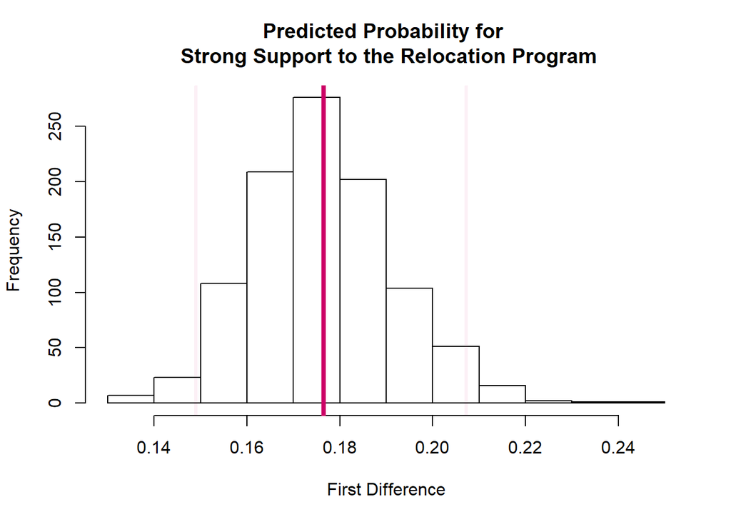

```r
hist(pp,
     main = "Predicted Probability for \n Strong Support to the Relocation Program",
     xlab = "First Difference")
abline(v = mean(pp), col = "#CC0066", lwd = 4)
abline(v = quantile(pp, 0.025), col = "#CC00660F", lwd = 3)
abline(v = quantile(pp, 0.975), col = "#CC00660F", lwd = 3)
```

#### First Difference

Let’s see what is the first difference in support of the program for those individuals who strongly support and strongly oppose giving vsas for immigrants.

```r
# Typical Case Approach using the canned functions
NewData1 <- data.frame(emp=0,
                      mig_visas=5,
                      democrat=0,
                      republican=0,
                      white=1,
                      black=0,
                      hispanic=0,
                      edu=median(final$edu),
                      female=1,
                      inc=mean(final$inc),
                      age=mean(final$age))
NewData2 <- data.frame(emp=0,
                      mig_visas=1,
                      democrat=0,
                      republican=0,
                      white=1,
                      black=0,
                      hispanic=0,
                      edu=median(final$edu),
                      female=1,
                      inc=mean(final$inc),
                      age=mean(final$age))
fdiff <- predict(m1, newdata = NewData2, type = "probs") - predict(m1, newdata = NewData1, type = "probs")
round(mean(fdiff),3)
```

```
## [1] 0
```

```r
# Food for thought: How would you calculate this quantity of interest using the optimization results?

# Observed Value Approach using canned functions
x <- model.matrix(m1)[ ,-1]
x[, "mig_visas"] <- 5
pp0 <- 1 - pnorm(tau[,6] - beta %*% t(x))
pp0 <- apply(pp0, 1, mean)
x[, "mig_visas"] <- 1
pp1 <- 1 - pnorm(tau[,6] - beta %*% t(x))
pp1 <- apply(pp1, 1, mean)
mean(pp0); mean(pp1)
```

```
## [1] 0.02799384
```

```
## [1] 0.5457775
```

```r
fdiff <- (pp1 - pp0)*100
round(mean(fdiff),3)
```

```
## [1] 51.778
```

```r
# Observed Value Approach using the optimization inputs/results
x <- X
x[, "mig_visas"] <- 5
pp0 <- 1 - pnorm(tau[,6] - beta %*% t(x))
pp0 <- apply(pp0, 1, mean)
x[, "mig_visas"] <- 1
pp1 <- 1 - pnorm(tau[,6] - beta %*% t(x))
pp1 <- apply(pp1, 1, mean)
mean(pp0); mean(pp1)
```

```
## [1] 0.02799384
```

```
## [1] 0.5457775
```

```r
fdiff <- (pp1 - pp0)*100
round(mean(fdiff),3)
```

```
## [1] 51.778
```

```r
# Let's calculate uncertainty for the first difference using the canned functions
fd_mat<-matrix(NA, 7,3)
x0 <- x1 <- X
x0[, "mig_visas"] <- 5
x1[, "mig_visas"] <- 1
fd_mat[,1] <- apply(predict(m1, newdata = x1, type = "probs") -
                      predict(m1, newdata = x0, type = "probs"),
                    2, mean)
# Let's calculate the uncertainty now
# Recall our simmulated data

# First let's create a matrix of predicted taus coming from the simmulations
taupred <- array(NA, c(1000, 8))                                       # Container array nSimsX(J+1), we need an array to include the infinite
taupred[ ,1] <- -Inf                                                   # Minimum value of tau
taupred[ ,8] <- Inf                                                    # Maximum value of tau
taupred[ ,2:7] <- tau                                                  # our simulated taus
head(taupred)
```

```
##      [,1]      [,2]      [,3]      [,4]      [,5]       [,6]        [,7] [,8]
## [1,] -Inf -3.506408 -3.227993 -2.739486 -1.898294 -1.3979301 -0.54181064  Inf
## [2,] -Inf -3.207598 -2.841741 -2.483209 -1.484386 -0.9451470 -0.24780236  Inf
## [3,] -Inf -2.885357 -2.578269 -2.161584 -1.262820 -0.7587574 -0.07300656  Inf
## [4,] -Inf -3.782264 -3.495770 -3.059780 -2.195266 -1.7596374 -1.00952753  Inf
## [5,] -Inf -3.101750 -2.795947 -2.378915 -1.495931 -0.9669177 -0.36111236  Inf
## [6,] -Inf -3.033982 -2.773704 -2.251185 -1.440011 -0.9239780 -0.18278340  Inf
```

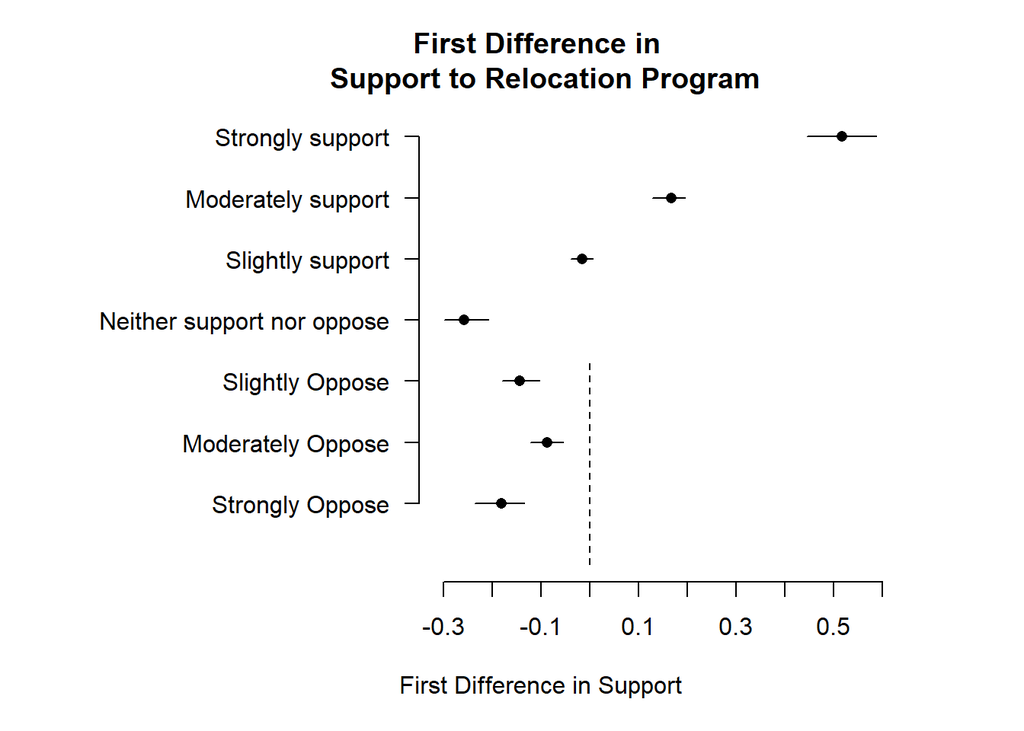

```r
fd <- list()
for(i in 1:7) {
  fd[[i]] <- rowMeans(apply(x1, 1, function(data_mat) pnorm(taupred[ ,i+1] - beta %*% data_mat) -
                              pnorm(taupred[ ,i] - beta %*% data_mat))) -
    rowMeans(apply(x0, 1, function(data_mat) pnorm(taupred[ ,i+1] - beta %*% data_mat) -
                     pnorm(taupred[ ,i] - beta %*% data_mat)))
}
fd_mat[,2] <- sapply(fd, function(z) quantile(z, 0.025))
fd_mat[,3] <- sapply(fd, function(z) quantile(z, 0.975))

plot(fd_mat[1:7], 1:7, xlab = "First Difference in Support",
     ylab = "", main = "First Difference in \n Support to Relocation Program",
     pch = 16, ylim = c(0.0, 7), xlim = c(-0.9, 0.7), axes = F)
axis(1, c(-0.3, -0.2, -0.1, 0, 0.1, 0.2, 0.3, 0.4, 0.5, 0.6))
axis(2, 1:7, labels = c("Strongly Oppose", "Moderately Oppose",
                        "Slightly Oppose", "Neither support nor oppose",
                        "Slightly support", "Moderately support",
                        "Strongly support"),
     las = 1, pos = -0.35)
segments(fd_mat[8:14], 1:7, fd_mat[15:21], 1:7)
segments(x0=0,y0=0,x1=0,y1=3.3,col="black", lty=2)
```

### Measures of Fit

We can use the same measures of fit for the ordinal variable models as in the binary models from last wek.

```r
MeasFit <- matrix(NA, 4,1)
rownames(MeasFit) <- c("pcp", "pmp", "pre", "epcp")
colnames(MeasFit) <- c("Values")

Mode <- function(x) {
  ux <- unique(x)
  ux[which.max(tabulate(match(x, ux)))]
}

# PCP
pcp <- mean(predict(m1, type = "class") == y)
MeasFit[1] <- pcp
# 36% of the time, the model guess is the observed value. In-sample prediction is 36%

# PRE
pmp <- mean(y == Mode(y))
MeasFit[2] <- pmp
# the mode, which guesses 4 every time, is correct 24% of the time

pre <- (pcp - pmp) / (1 - pmp)
MeasFit[3] <- pre
# we have a proportionate reduction in error of 16%

## ePCP (punishes those that predict with low probabilities)
pp <- matrix(NA, 7,1)
for(i in 1:7) { # for each category in the DV
  pp[i,1] <- sum(predict(m1, type = "probs")[y == i, i])
}
epcp <- sum(p) / length(y)
MeasFit[4] <- epcp

round(MeasFit, 2)
```

```
##      Values
## pcp    0.36
## pmp    0.24
## pre    0.16
## epcp   0.03
```

## **Additional Resources**

- [Data Visualization in R](https://rkabacoff.github.io/datavis/)
- Prof. Stegmueller has mentioned the [Delta Method](https://www.statlect.com/asymptotic-theory/delta-method) multiple times.